# Exploration of Petroleum Rock Samples

*Adam McCarthy*

Exploratory data analysis of rock core barrel scans and their permeability.

Data-set consists of four variables. Of these permeability could be thought of as a dependent variable. While the other variables are assumed to be independent.

- area = area of pores space, in pixels out of 256 by 256
- peri = perimeter in pixels
- shape = perimeter/sqrt(area)
- perm = permeability in milli-Darcies

There is little information about these variables and data-set.

Either this was from microscopy or CT scans of the cross-sections of core.

The source information is:

> Data from BP Research, image analysis by Ronit Katz, U. Oxford.

The details state that information comes from 12 core samples with 4 cross-sections taken.

4 cross sections from 12 cores give 48 samples.

#### Descriptive Statistics

```
##       area            peri            shape              perm
##  Min.   : 1016   Min.   : 308.6   Min.   :0.09033   Min.   :   6.30
##  1st Qu.: 5305   1st Qu.:1414.9   1st Qu.:0.16226   1st Qu.:  76.45
##  Median : 7487   Median :2536.2   Median :0.19886   Median : 130.50
##  Mean   : 7188   Mean   :2682.2   Mean   :0.21811   Mean   : 415.45
##  3rd Qu.: 8870   3rd Qu.:3989.5   3rd Qu.:0.26267   3rd Qu.: 777.50
##  Max.   :12212   Max.   :4864.2   Max.   :0.46413   Max.   :1300.00
##     perm_c
##  Length:48
##  Class :character
##  Mode  :character
##
##
##
```

The summary of the data-set highlights the distribution of the data. The data consist of four original variables and one categorical variable created based on a permeability cut-off of 300mD (milli-Darcies). The categorical variable is to highlight the difference between relatively poor (“low”) and better (“permeable”) reservoir.

All original variables are numeric.

Area of pore space is measured out of pixels of 256 by 256. This gives a total number of pixels of 65536. So the maximum value has pore space of ~19% compared to non-pore space. Following this approach a new variable is calculated to give area as a percentage as this is easier to comprehend.

The perimeter would count the geometric boundary of the pore space in pixels. There is no information present to convert this into a measurement.

Shape would reflect some information about the shape of the pore space. No information is at hand other than it is perimeter/sqrt(area)

Permeability has very low values at it´s minimum of 6.3 mD up to a max of 1300mD.

#### Checking data

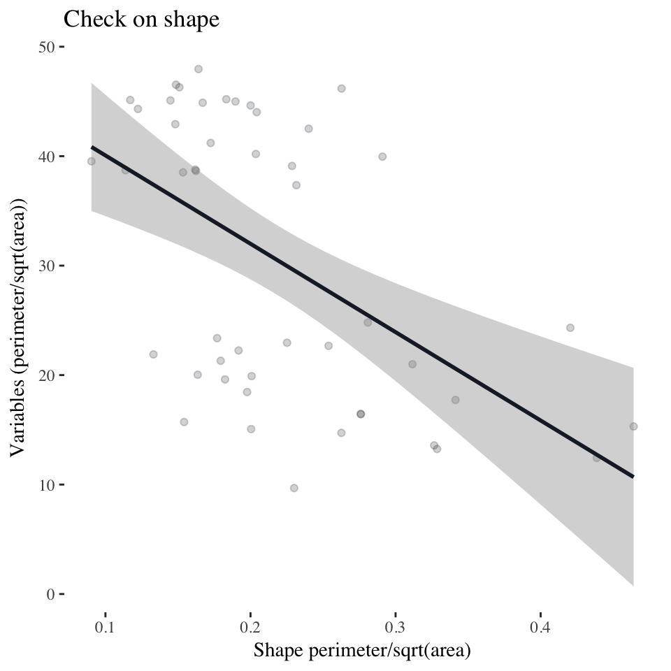

The first plot is made to check what the shape variable is based on. In the notes it is described as perimeter/sqrt(area) but when plotted against this axis they do not correlate. If the shape variable was a derivative of area and perimeter then this would be a matching along a straight line.

This would imply that shape has been calculated on each individual pore rather than the sum for each cross-section, which is what is at hand.

The ratio would suggest that for the same perimeter larger pores would have lower values. While if the perimeter was larger for the same pore area the value would be larger.

Circular pores with an even shape would have larger pore area compared to perimeter so would have lower values. While highly irregular geometric shapes would have a longer perimeter for their area given higher values.

The tricky thing here is we are dealing with the sum of these values for the cross section. So this is an aggregate of all these values.

#### Uni-varaite analysis

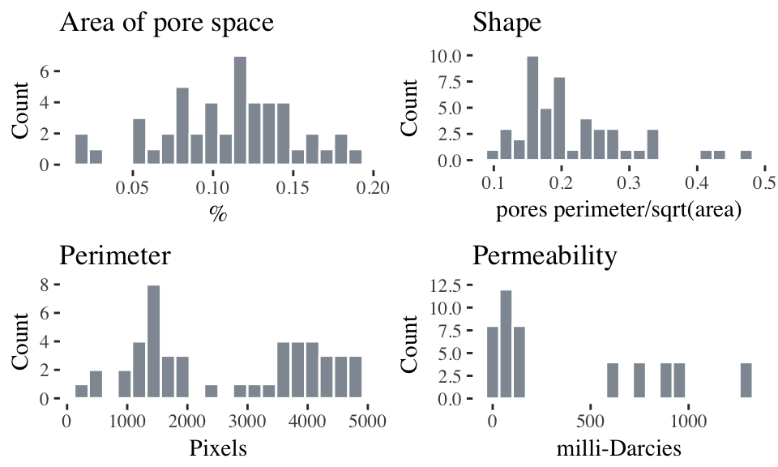

Histogram better represent the distribution of values. Given 48 samples only 20 bins have been used.

The Area of pore space shows an apparent normal distribution.

Shape shows a skewed distribution.

Perimeter shows a bi modal distribution.

Permeability shows a large group of values close to 0 and then groups of bars above 500mD. A cut-off of 300mD has been used as an arbitary number to seperate between low and high values.

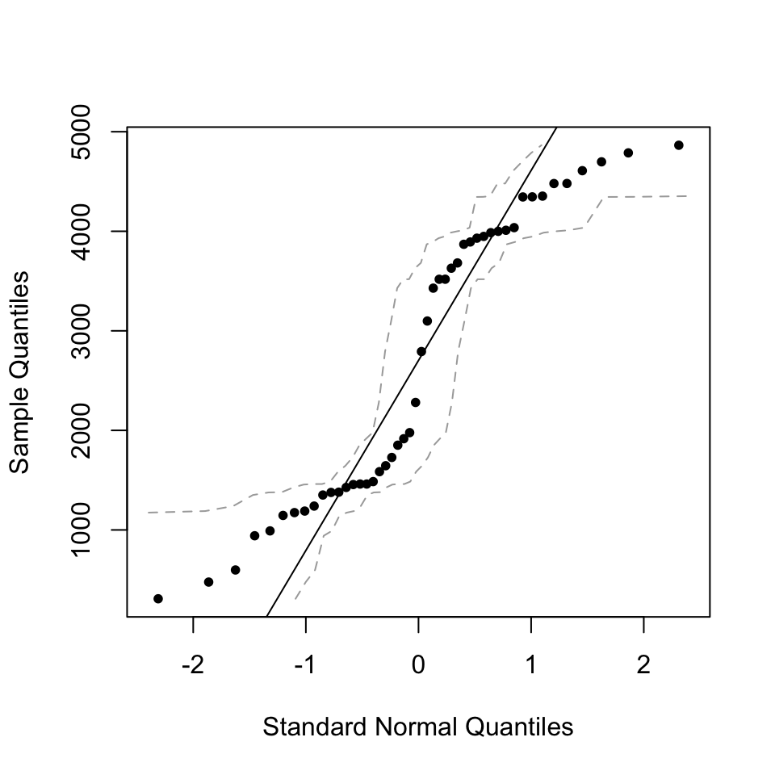

Checking perimeter in a QQ plot highlights the bi modal distribution. Given the sparse number of samples the confidence bands highlight that it may still be sourced from a normal distribution.

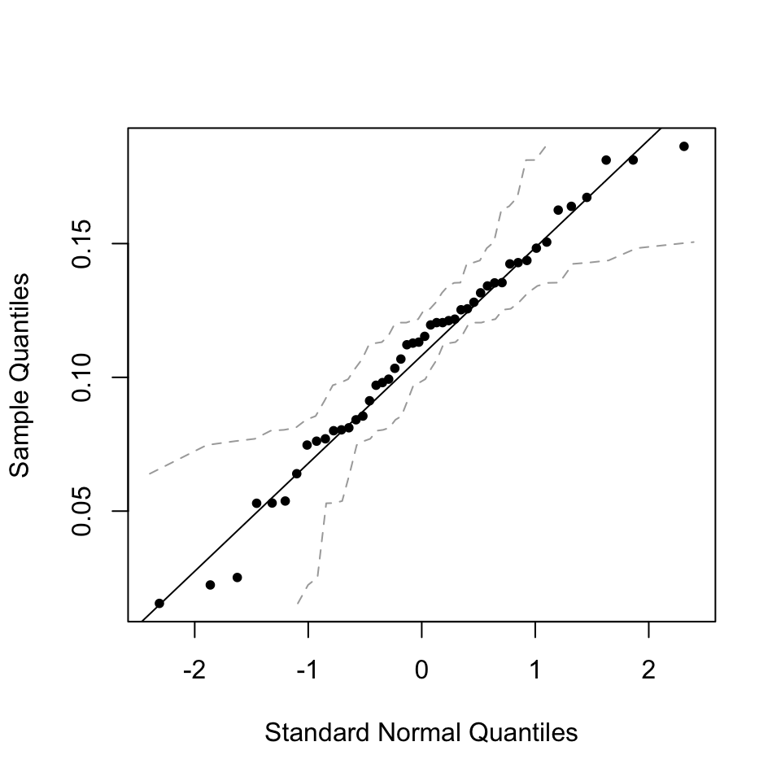

Area of pore space does show a normal distribution, one with a number of clusters in this data-set.

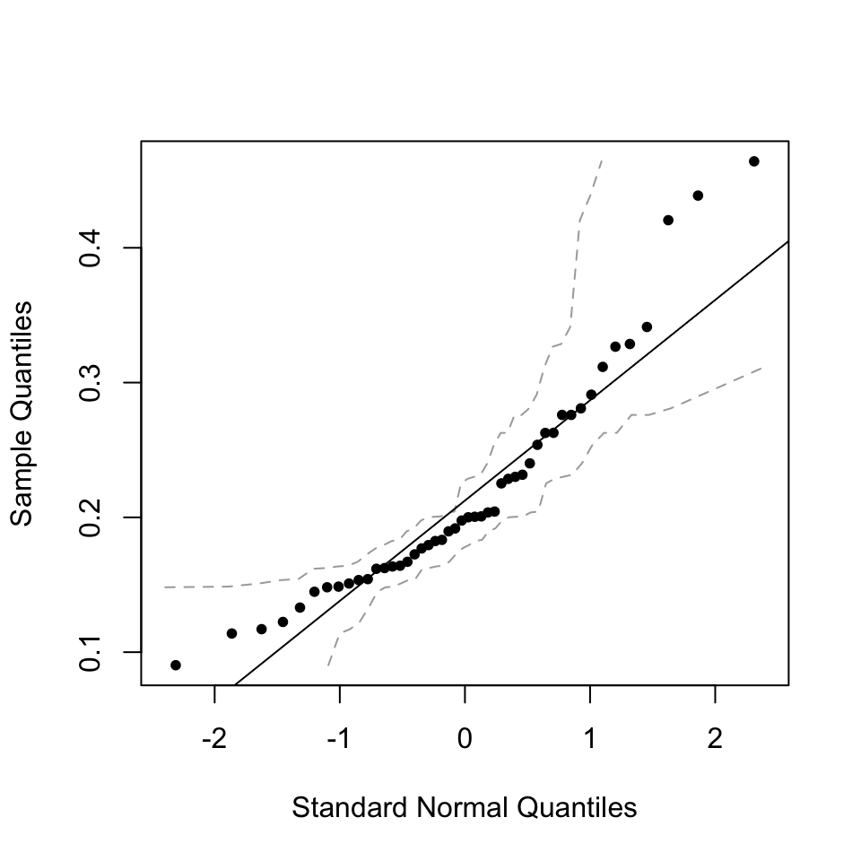

Shape shows it skews to the right, it intersects the confidence interval suggesting that even with this number of data points it is unlikely it is sourced from a normal distribution.

All of these observations, however, should be treated with caution, we are dealing with 12 core samples, perhaps from a very similar setting. This does not mean these observations may be relevant for a broader sample or the population of values.

#### Bi-variate analysis

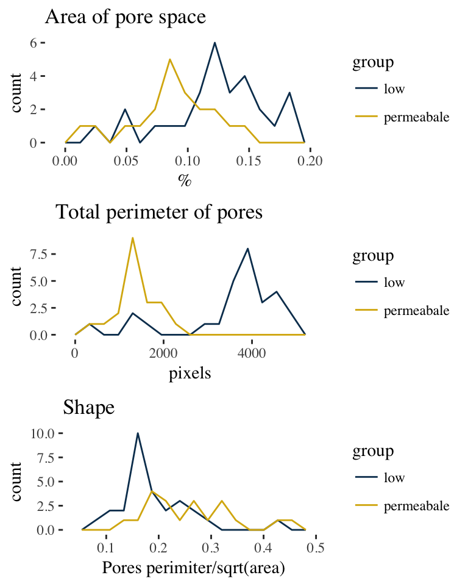

Using the categorical variable separating permeability each variable shows some relationship to permeability.

The first plot shows spikes where there are fewer permeable samples with an increase in pore area. This in counter-intuitive as an initial perspective would be more pore space would lead to more permeability.

The second plot suggests that the total length of pore perimeter has a strong relationship to the two bi modal peaks of perimeter. In which permeable reservoirs have a lower total perimeter.

The final plot showing the shape variable gives lower values as having low permeability. These would be the more uniform circular geometries. More irregular geometries would give some of the permeable results but there are also low values here as well.

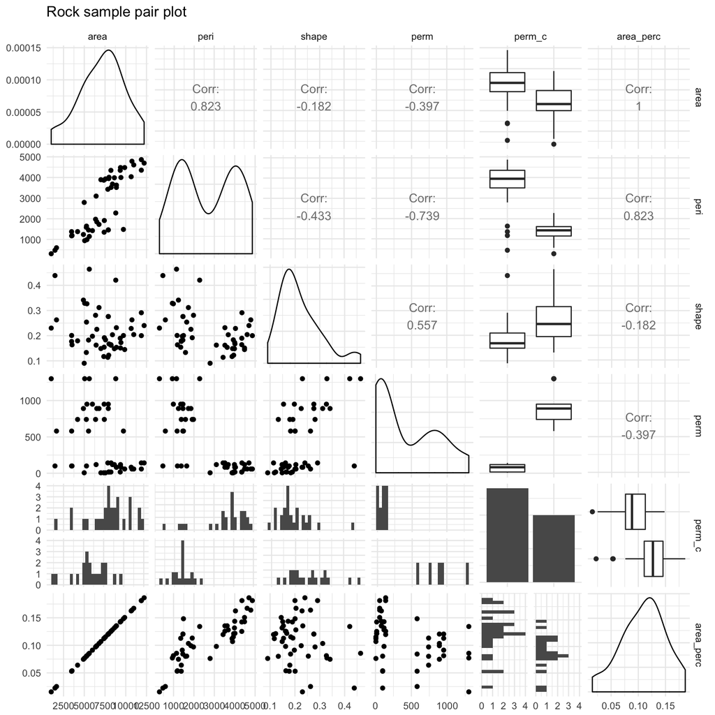

The most correlated variables are area and perimeter (0.82).

Permeability shows correlations to all three variables with -0.74 to perimeter being the strongest.

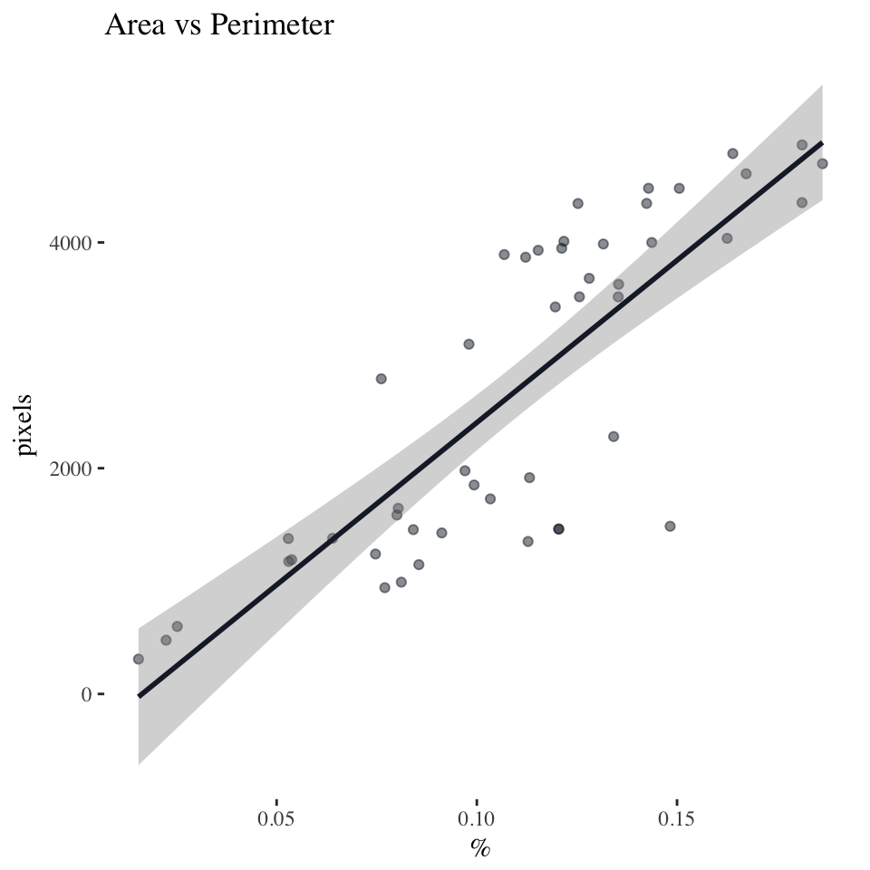

Area compared to perimeter has the highest correlation of 0.82, the plot of these two variables highlights this falls into two clusters. Overall it suggests a larger area has a larger overall perimeter length which would make sense.

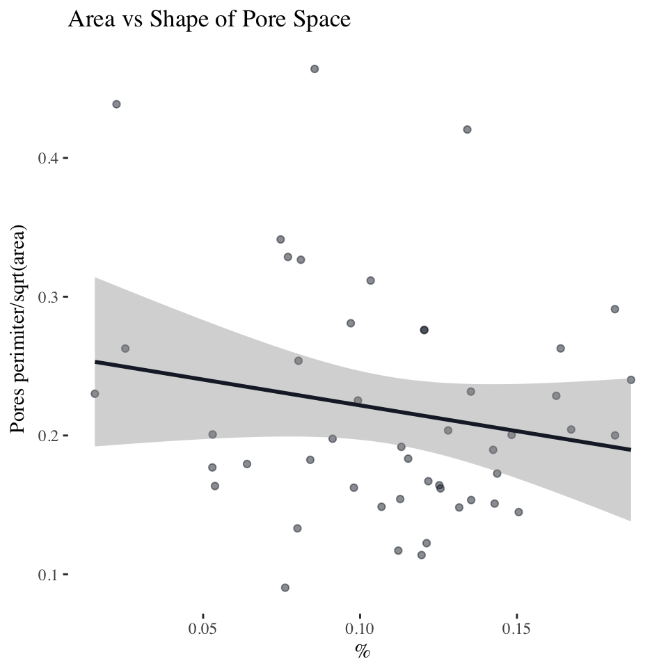

Area compared to shape does not show any clear correlations. Different sums for pore shape geometry can occur for different total areas.

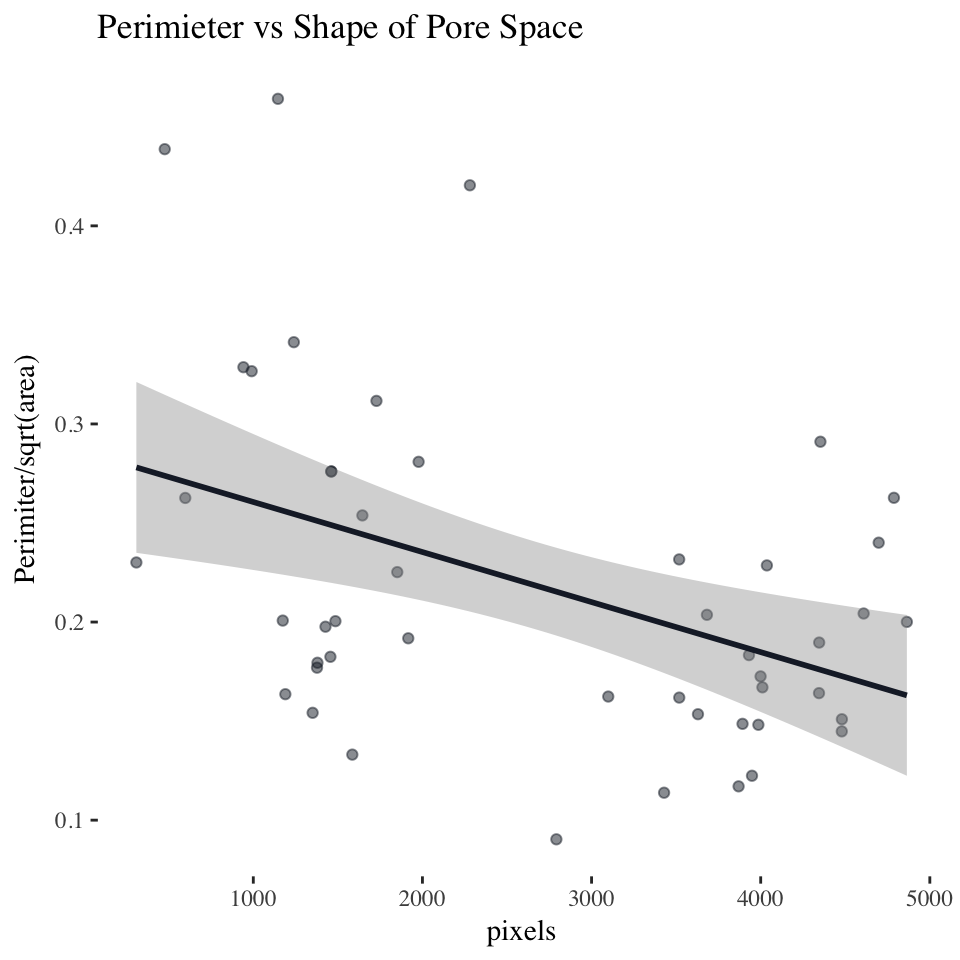

Perimeter of pore space compared to the shape gives two clusters along the x axis (perimeter) each having a range of shapes.

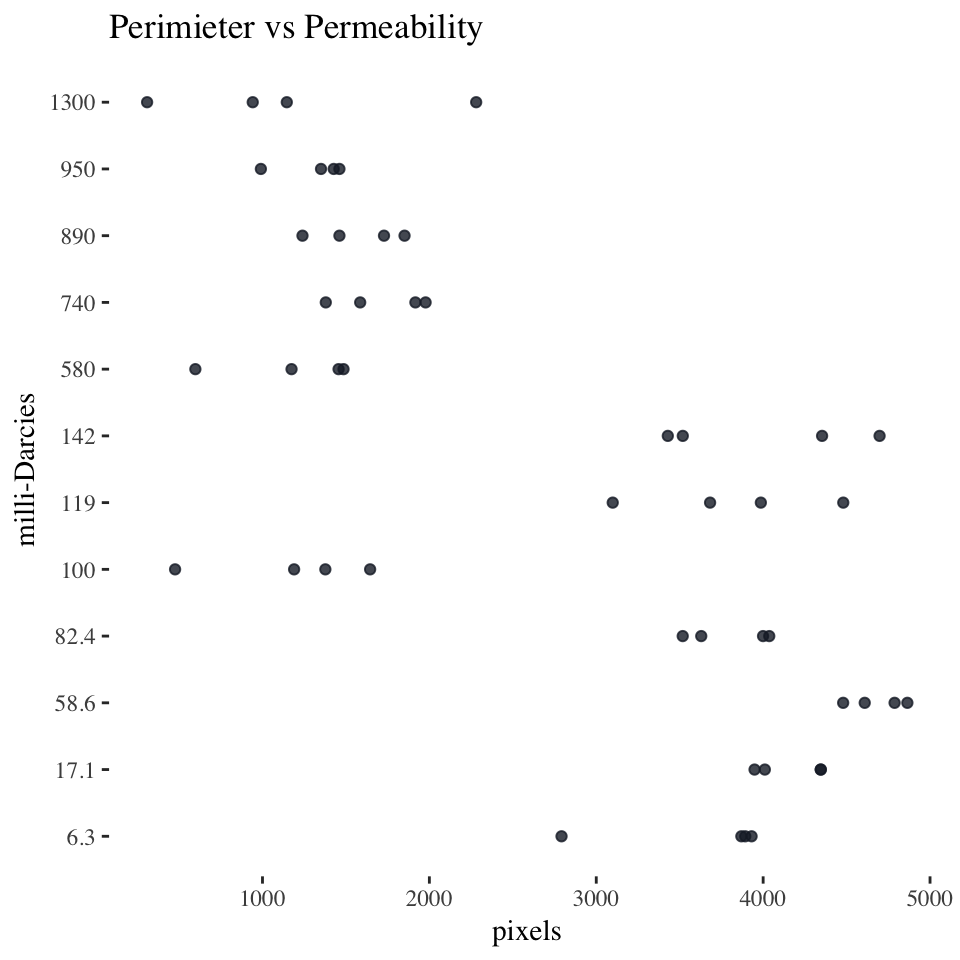

Starting to compare the variables to the dependent permeability perimeter had the highest correlation. The two clusters in perimeter appear to relate to to different trends in permeability. With lower perimeter lengths relating to higher permeability.

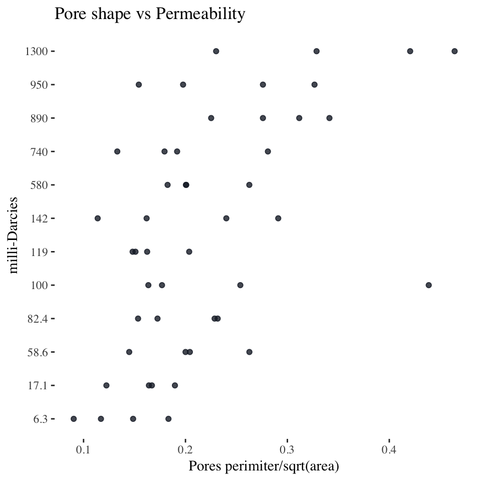

Pore shape compared to permeability suggest that the highest values of pore shape are often associated to higher permeability with one outlier. There is a lot of overlap in pore shape values and the range of permeability.

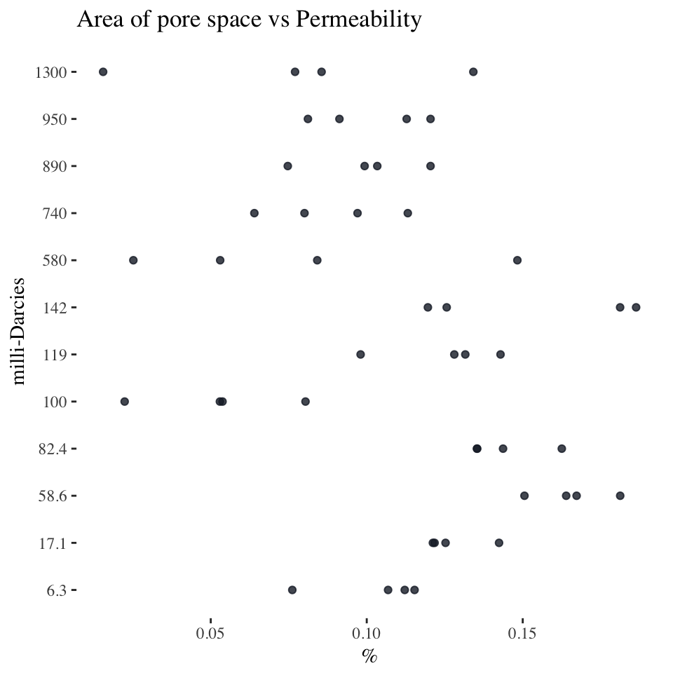

Area of pore space shows a confusing plot with each value of permeability having a range of pore areas. Often highest pore area has lowest permeability.

#### Multi-variate analysis

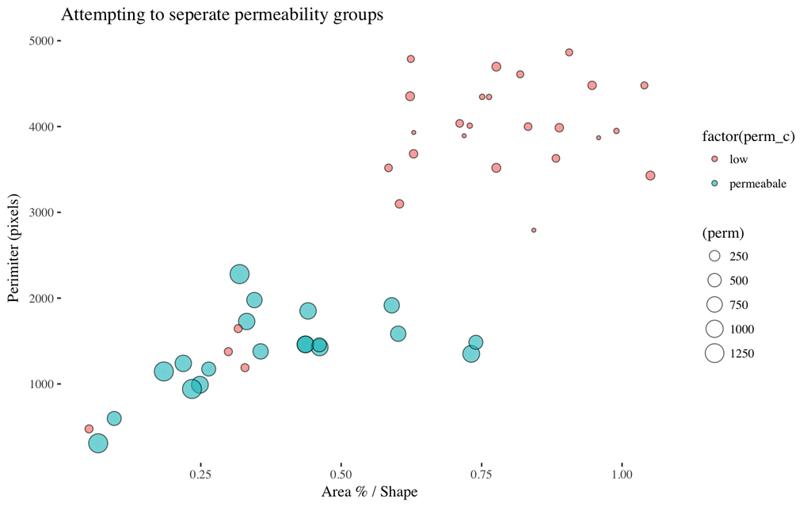

After struggling to find strong relationships between individual variables and permeability this leads to multi-variate analysis. Using two variables as ratios compared to a third variable will allow to explore if it is possible to separate out different permeability groups. As perimeter has the strongest relationship to permeability this is kept on one axis while area and shape are combined into a ratio for the x axis.

The figure shows the best visual representation of separating the low and permeable intervals. This plot suggests, for this data-set, that relatively lower perimeter values strongly separate permeable reservoir units.

The combination of pore area and pore shape further help separate out this trend. Lower values of this ratio equate to lower pore area and more irregular pore geometries.

This is the trends apparent in this data-set, however, these observations are counter intuitive. The greater the pore area, with longer pore perimeters would be associated with being easier for fluids to flow through. Less interfacial tension between grains and thus higher permeability values.

It could relate to micro vs. macro pore space as permeability is controlled by macro pore space rather than micro. Given that all these values are sums for the cross section if micro pore spaces are included this could be creating the greater area values and greater perimeter values. Furthermore, the irregular pore space being associated with more permeable layers may reflect this trend with micro-pores being typically more uniform. So if the sample is dominated by macro pores, perhaps this is reflected in the sum of the pore shape values.

This could be a reflection of local conditions from where these cores are taken from. For example carbonate compared to siliciclastic depositional settings.

Diagenesis, chemical alterations during burial of sediments can lead to fibrous growths (e.g. illite cement) between pore spaces which can have dramatic effects on permeability while retaining large pore spaces.

Without further information about the local conditions of each core sample it is not possible to take this assessment any further. The observations presented here should not be generalized to other similar data-sets.

[figure not shown]

The final plot separates out all of the permeability values, this also highlights that there are only 12 measurements of permeability out of all 48 samples. This reflects that each core likely only has one permeability measurement. So even though there are 48 samples there are only 12 samples of permeability. Based on this assumption the above plot shows each core and their four values.

Each of these plots shows a certain grouping but there is variance in the values of each cross-section within each core. There is less variation in perimeter (y axis) compared to the range in the x axis (Area/Shape).